# Day_23_Project

### *Name : Syed Riaz Ali*

### *Email : syedriazali1997@gmail.com*

### *Whatsapp : 0300-2502513*

### *Day 23 : Project Making Assignment*

This notebook predicted the quality of red wine by using machine learning algorithms of the most popular and useful library scikit-learn.

I have used 3 algorithms of supervised machine learning which are as follows

1. Linear regression
2. Decision Tree Classification
3. K Nearest Neighbor

# Table of content

1. Exploratory Data Analysis\ 2. Corelation between variables\ 3. Dependence of quality of Red Wine on different parameters\ 4. Linear Regression Algorithm\ 5. Dependence of bin quality of Red Wine on different parameters\ 6. Decision Tree Classification\ 7. K Nearest Neighbor

## 1. Exploratory Data Analysis

```python
# Importing libraries

import pandas as pd
import numpy as np
import matplotlib.pyplot as plt
import seaborn as sns

# Loading dataset

df = pd.read_csv("winequality-red.csv")
df.head()
```

|  | fixed acidity | volatile acidity | citric acid | residual sugar | chlorides | free sulfur dioxide | total sulfur dioxide | density | pH | sulphates | alcohol | quality |
| --- | --- | --- | --- | --- | --- | --- | --- | --- | --- | --- | --- | --- |
| 0 | 7.4 | 0.70 | 0.00 | 1.9 | 0.076 | 11.0 | 34.0 | 0.9978 | 3.51 | 0.56 | 9.4 | 5 |
| 1 | 7.8 | 0.88 | 0.00 | 2.6 | 0.098 | 25.0 | 67.0 | 0.9968 | 3.20 | 0.68 | 9.8 | 5 |
| 2 | 7.8 | 0.76 | 0.04 | 2.3 | 0.092 | 15.0 | 54.0 | 0.9970 | 3.26 | 0.65 | 9.8 | 5 |
| 3 | 11.2 | 0.28 | 0.56 | 1.9 | 0.075 | 17.0 | 60.0 | 0.9980 | 3.16 | 0.58 | 9.8 | 6 |
| 4 | 7.4 | 0.70 | 0.00 | 1.9 | 0.076 | 11.0 | 34.0 | 0.9978 | 3.51 | 0.56 | 9.4 | 5 |

```python
# Now, let's check the information about different variables/column from the dataset:
df.info()
```

```
<class 'pandas.core.frame.DataFrame'>
RangeIndex: 1599 entries, 0 to 1598
Data columns (total 12 columns):
 #   Column                Non-Null Count  Dtype
---  ------                --------------  -----
 0   fixed acidity         1599 non-null   float64
 1   volatile acidity      1599 non-null   float64
 2   citric acid           1599 non-null   float64
 3   residual sugar        1599 non-null   float64
 4   chlorides             1599 non-null   float64
 5   free sulfur dioxide   1599 non-null   float64
 6   total sulfur dioxide  1599 non-null   float64
 7   density               1599 non-null   float64
 8   pH                    1599 non-null   float64
 9   sulphates             1599 non-null   float64
 10  alcohol               1599 non-null   float64
 11  quality               1599 non-null   int64
dtypes: float64(11), int64(1)
memory usage: 150.0 KB
```

- We can see that, all 12 columns are of numeric data types. Out of 12 variables, 11 are predictor variables and last one 'quality' is an response variable

```python
# Let's look at the summary of the dataset,
df.describe()
```

|  | fixed acidity | volatile acidity | citric acid | residual sugar | chlorides | free sulfur dioxide | total sulfur dioxide | density | pH | sulphates | alcohol | quality |
| --- | --- | --- | --- | --- | --- | --- | --- | --- | --- | --- | --- | --- |
| count | 1599.000000 | 1599.000000 | 1599.000000 | 1599.000000 | 1599.000000 | 1599.000000 | 1599.000000 | 1599.000000 | 1599.000000 | 1599.000000 | 1599.000000 | 1599.000000 |
| mean | 8.319637 | 0.527821 | 0.270976 | 2.538806 | 0.087467 | 15.874922 | 46.467792 | 0.996747 | 3.311113 | 0.658149 | 10.422983 | 5.636023 |
| std | 1.741096 | 0.179060 | 0.194801 | 1.409928 | 0.047065 | 10.460157 | 32.895324 | 0.001887 | 0.154386 | 0.169507 | 1.065668 | 0.807569 |
| min | 4.600000 | 0.120000 | 0.000000 | 0.900000 | 0.012000 | 1.000000 | 6.000000 | 0.990070 | 2.740000 | 0.330000 | 8.400000 | 3.000000 |
| 25% | 7.100000 | 0.390000 | 0.090000 | 1.900000 | 0.070000 | 7.000000 | 22.000000 | 0.995600 | 3.210000 | 0.550000 | 9.500000 | 5.000000 |
| 50% | 7.900000 | 0.520000 | 0.260000 | 2.200000 | 0.079000 | 14.000000 | 38.000000 | 0.996750 | 3.310000 | 0.620000 | 10.200000 | 6.000000 |
| 75% | 9.200000 | 0.640000 | 0.420000 | 2.600000 | 0.090000 | 21.000000 | 62.000000 | 0.997835 | 3.400000 | 0.730000 | 11.100000 | 6.000000 |
| max | 15.900000 | 1.580000 | 1.000000 | 15.500000 | 0.611000 | 72.000000 | 289.000000 | 1.003690 | 4.010000 | 2.000000 | 14.900000 | 8.000000 |

```python
#Let's look for the missing values in red wine dataset:

df.isnull().sum()
```

```
fixed acidity           0
volatile acidity        0
citric acid             0
residual sugar          0
chlorides               0
free sulfur dioxide     0
total sulfur dioxide    0
density                 0
pH                      0
sulphates               0
alcohol                 0
quality                 0
dtype: int64
```

- The red wine dataset doesn't have any missing values/rows/cells for any of the variables/feature.
- It seems that data has been collected neatly or prior cleaning has been performed before publishing the dataset.

### Learning more about the target/response variable/feature

```python
# Let's check how many unique values does the target feature 'quality' has?

df["quality"].unique()
```

```
array([5, 6, 7, 4, 8, 3], dtype=int64)
```

```python
df["quality"].value_counts().sort_index()
```

```
3     10
4     53
5    681
6    638
7    199
8     18
Name: quality, dtype: int64
```

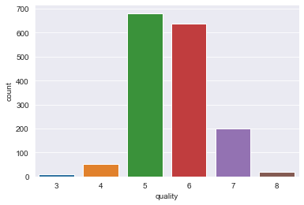

```python
sns.set_style("darkgrid")
sns.countplot(x='quality', data=df)
```

```python
df['bin_quality'] = pd.cut(df['quality'], bins=[0, 6.5, 10], labels=["bad", "good"])
df.head()
```

|  | fixed acidity | volatile acidity | citric acid | residual sugar | chlorides | free sulfur dioxide | total sulfur dioxide | density | pH | sulphates | alcohol | quality | bin_quality |
| --- | --- | --- | --- | --- | --- | --- | --- | --- | --- | --- | --- | --- | --- |
| 0 | 7.4 | 0.70 | 0.00 | 1.9 | 0.076 | 11.0 | 34.0 | 0.9978 | 3.51 | 0.56 | 9.4 | 5 | bad |
| 1 | 7.8 | 0.88 | 0.00 | 2.6 | 0.098 | 25.0 | 67.0 | 0.9968 | 3.20 | 0.68 | 9.8 | 5 | bad |
| 2 | 7.8 | 0.76 | 0.04 | 2.3 | 0.092 | 15.0 | 54.0 | 0.9970 | 3.26 | 0.65 | 9.8 | 5 | bad |
| 3 | 11.2 | 0.28 | 0.56 | 1.9 | 0.075 | 17.0 | 60.0 | 0.9980 | 3.16 | 0.58 | 9.8 | 6 | bad |
| 4 | 7.4 | 0.70 | 0.00 | 1.9 | 0.076 | 11.0 | 34.0 | 0.9978 | 3.51 | 0.56 | 9.4 | 5 | bad |

```python
df.groupby("bin_quality").mean()
```

| bin_quality | fixed acidity | volatile acidity | citric acid | residual sugar | chlorides | free sulfur dioxide | total sulfur dioxide | density | pH | sulphates | alcohol | quality |
| --- | --- | --- | --- | --- | --- | --- | --- | --- | --- | --- | --- | --- |
| bad | 8.236831 | 0.547022 | 0.254407 | 2.512120 | 0.089281 | 16.172214 | 48.285818 | 0.996859 | 3.314616 | 0.644754 | 10.251037 | 5.408828 |
| good | 8.847005 | 0.405530 | 0.376498 | 2.708756 | 0.075912 | 13.981567 | 34.889401 | 0.996030 | 3.288802 | 0.743456 | 11.518049 | 7.082949 |

## *2. Corelation between variables*

A positive correlation means that as the value of the first parameter increases, so will the second one. For example, with a higher content of acid in the red wine, the wine has a higher density, since the acids themselves are denser than water.

A negative correlation means that as the value of the first parameter increases, the value of the second parameter decreases. For example, with a higher acid content in red wine, the pH value will be lower, indicating an acidic environment.

The closer the correlation value is to zero, the less the parameters affect each other.

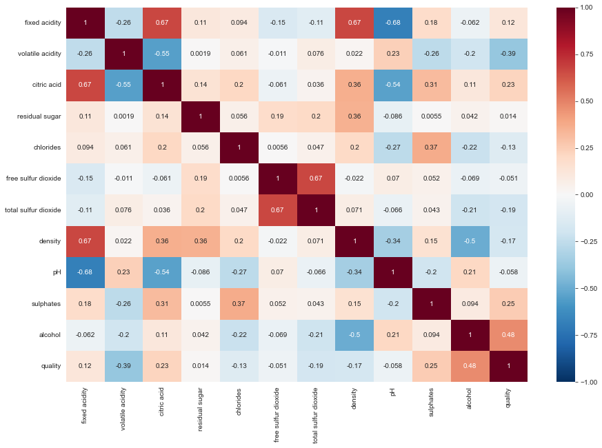

```python
correlation = df.corr()
plt.figure(figsize=(15, 10))
sns.heatmap(correlation, annot=True, linewidths=0, vmin=-1, cmap="RdBu_r")
```

```python
correlation['quality'].sort_values(ascending=False)
```

```
quality                 1.000000
alcohol                 0.476166
sulphates               0.251397
citric acid             0.226373
fixed acidity           0.124052
residual sugar          0.013732
free sulfur dioxide    -0.050656
pH                     -0.057731
chlorides              -0.128907
density                -0.174919
total sulfur dioxide   -0.185100
volatile acidity       -0.390558
Name: quality, dtype: float64
```

- We can observe that, the *"alcohol", "sulphates", "citric acid", "fixed acidity" & "residual sugar"* are directly proportional to the response variable *'quality'*.
- Also *"free sulfur dioxide", "pH", "chlorides", "density", "total sulfur dioxide" & "volatile acidity"* are inversely proportional to *"quality"*.
- For simplicity we take few variables in our model which includes *"alcohol", "sulphates", "citric acid", "fixed acidity"*.Hence, we will use only these 4 variables in our future analysis.

## *3. Dependence of quality of Red Wine on different parameters*

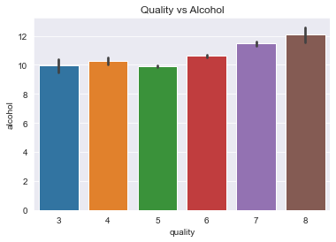

```python
# Quality vs Alcohol
sns.barplot(data = df, x = "quality", y="alcohol")
plt.title("Quality vs Alcohol")
```

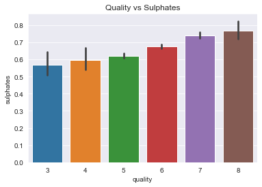

```python
# Quality vs sulphates
sns.barplot(data = df, x = "quality", y="sulphates")
plt.title("Quality vs Sulphates")
```

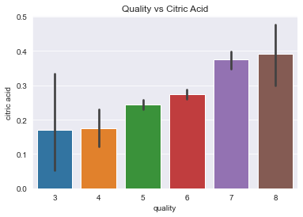

```python
# Quality vs Citric Acid
sns.barplot(data = df, x = "quality", y="citric acid")
plt.title("Quality vs Citric Acid")
```

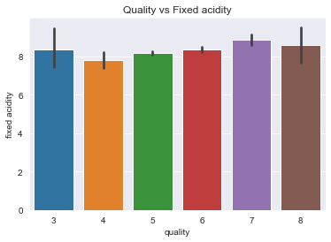

```python
# Quality vs fixed acidity
sns.barplot(data = df, x = "quality", y="fixed acidity")
plt.title("Quality vs Fixed acidity")
```

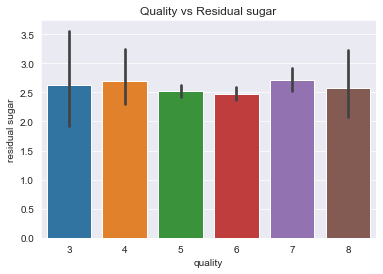

```python
# Quality vs Residual sugar
sns.barplot(data = df, x = "quality", y="residual sugar")
plt.title("Quality vs Residual sugar")
```

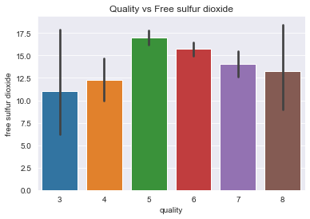

```python
# Quality vs Free sulfur dioxide
sns.barplot(data = df, x = "quality", y="free sulfur dioxide")
plt.title("Quality vs Free sulfur dioxide")
```

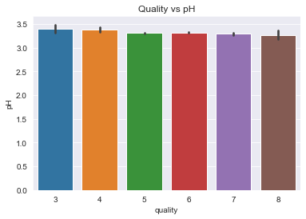

```python
# Quality vs pH
sns.barplot(data = df, x = "quality", y="pH")
plt.title("Quality vs pH")
```

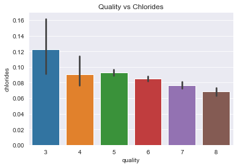

```python
# Quality vs Chlorides
sns.barplot(data = df, x = "quality", y="chlorides")
plt.title("Quality vs Chlorides")
```

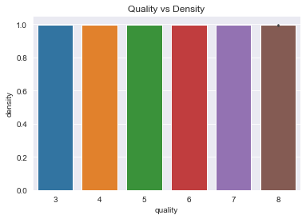

```python
# Quality vs Density
sns.barplot(data = df, x = "quality", y="density")
plt.title("Quality vs Density")
```

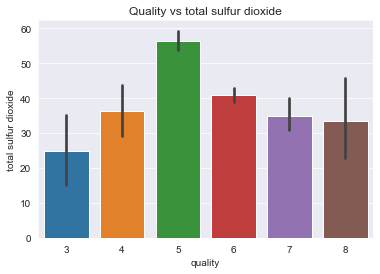

```python
# Quality vs total sulfur dioxide
sns.barplot(data = df, x = "quality", y="total sulfur dioxide")
plt.title("Quality vs total sulfur dioxide")
```

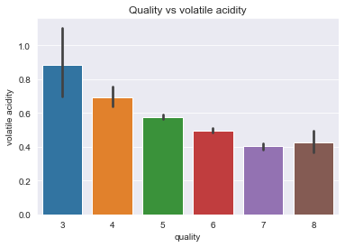

```python
# Quality vs volatile acidity
sns.barplot(data = df, x = "quality", y="volatile acidity")
plt.title("Quality vs volatile acidity")
```

## *4. Linear Regression Algorithm*

```python
# Viewing the data set

df.head()
```

|  | fixed acidity | volatile acidity | citric acid | residual sugar | chlorides | free sulfur dioxide | total sulfur dioxide | density | pH | sulphates | alcohol | quality | bin_quality |
| --- | --- | --- | --- | --- | --- | --- | --- | --- | --- | --- | --- | --- | --- |
| 0 | 7.4 | 0.70 | 0.00 | 1.9 | 0.076 | 11.0 | 34.0 | 0.9978 | 3.51 | 0.56 | 9.4 | 5 | bad |
| 1 | 7.8 | 0.88 | 0.00 | 2.6 | 0.098 | 25.0 | 67.0 | 0.9968 | 3.20 | 0.68 | 9.8 | 5 | bad |
| 2 | 7.8 | 0.76 | 0.04 | 2.3 | 0.092 | 15.0 | 54.0 | 0.9970 | 3.26 | 0.65 | 9.8 | 5 | bad |
| 3 | 11.2 | 0.28 | 0.56 | 1.9 | 0.075 | 17.0 | 60.0 | 0.9980 | 3.16 | 0.58 | 9.8 | 6 | bad |
| 4 | 7.4 | 0.70 | 0.00 | 1.9 | 0.076 | 11.0 | 34.0 | 0.9978 | 3.51 | 0.56 | 9.4 | 5 | bad |

```python
# Assigning the input values to the variables

X = df[["alcohol", "sulphates", "citric acid", "fixed acidity"]]
y = df["quality"]
```

```python
# Training and fit the model and getting some predicted values

from sklearn.linear_model import LinearRegression

model = LinearRegression().fit(X, y)

predict_value = model.predict([[9.5, 0.50, 0.02, 7.0]])
predict_value
```

```
array([5.06595458])
```

```python
# Checking the score of the Linear Regression Model

model.score(X,y)
```

```
0.28623144529798417
```

```python
# Testing the model by using the method of splitting the data into training and testing sets in the ratio of 80:20

from sklearn.model_selection import train_test_split
from sklearn.metrics import accuracy_score

X_train, X_test, y_train, y_test = train_test_split(X, y, test_size = 0.2)

model = LinearRegression().fit(X_train, y_train)

predict_value = model.predict(X_test)
predict_value
```

[output not shown]

[output cut: 9 more lines]

[output not shown]

```python
# Checking the score of the Linear Regression Model

model.score(X_train, y_train)
```

```
0.2830840176298671
```

```python
# Checking the score of the Linear Regression Model

model.score(X_test, y_test)
```

```
0.2971681105536491
```

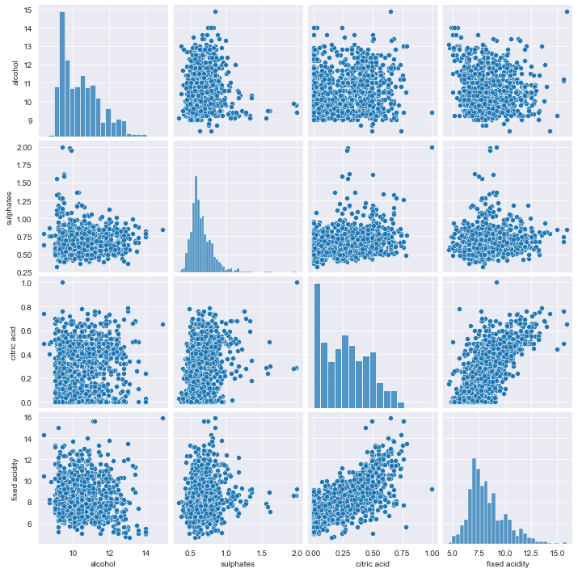

```python
sns.pairplot(X_train)
plt.show()
```

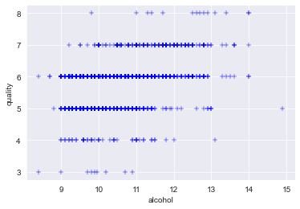

```python
# Alochol vs Quality

sns.scatterplot(x=X_train["alcohol"], y=y_train, color='blue', marker='+')
```

The above data shows that data is too scattered that the accuracy of our model is very low

```python
from sklearn.metrics import mean_squared_error

RMSE = mean_squared_error(y_true= y_test, y_pred= predict_value)
print(RMSE)
```

```
0.4474444697743854
```

## *5. Dependence of bin quality of Red Wine on different parameters*

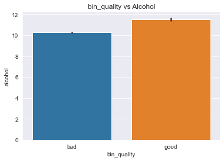

```python
# bin_quality vs Alcohol
sns.barplot(data = df, x = "bin_quality", y="alcohol")
plt.title("bin_quality vs Alcohol")
```

Increase in the alcohol quantity will increase the quality of the wine and vise versa

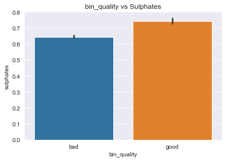

```python
# bin_quality vs sulphates
sns.barplot(data = df, x = "bin_quality", y="sulphates")
plt.title("bin_quality vs Sulphates")
```

Increase in the Sulpahtes quantity will increase the quality of the wine and vise versa

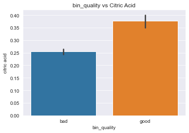

```python
# bin_quality vs Citric Acid
sns.barplot(data = df, x = "bin_quality", y="citric acid")
plt.title("bin_quality vs Citric Acid")
```

Increase in the Citric Acid quantity will increase the quality of the wine and vise versa

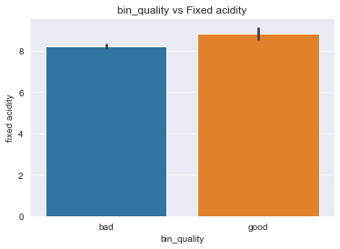

```python
# bin_quality vs fixed acidity
sns.barplot(data = df, x = "bin_quality", y="fixed acidity")
plt.title("bin_quality vs Fixed acidity")
```

Increase in the fixed acidity will increase the quality of the wine and vise versa

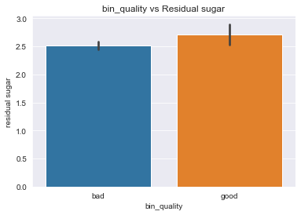

```python
# bin_quality vs Residual sugar
sns.barplot(data = df, x = "bin_quality", y="residual sugar")
plt.title("bin_quality vs Residual sugar")
```

Increase in the residual sugar will increase the quality of the wine and vise versa

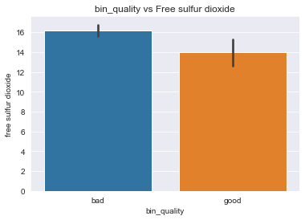

```python
# bin_quality vs Free sulfur dioxide
sns.barplot(data = df, x = "bin_quality", y="free sulfur dioxide")
plt.title("bin_quality vs Free sulfur dioxide")
```

Increase in the free sulphur dioxide will decrease the quality of the wine and vise versa

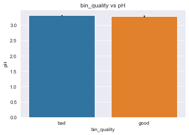

```python
# bin_quality vs pH
sns.barplot(data = df, x = "bin_quality", y="pH")
plt.title("bin_quality vs pH")
```

Increase in the free pH will slightly decrease the quality of the wine and vise versa

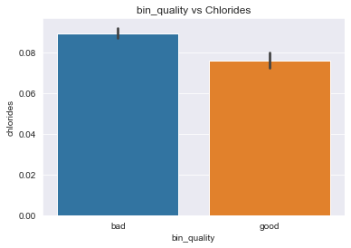

```python
# bin_quality vs Chlorides
sns.barplot(data = df, x = "bin_quality", y="chlorides")
plt.title("bin_quality vs Chlorides")
```

Increase in the chlorides will decrease the quality of the wine and vise versa

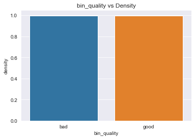

```python
# bin_quality vs Density
sns.barplot(data = df, x = "bin_quality", y="density")
plt.title("bin_quality vs Density")
```

Increase in the density will slightly decrease the quality of the wine and vise versa

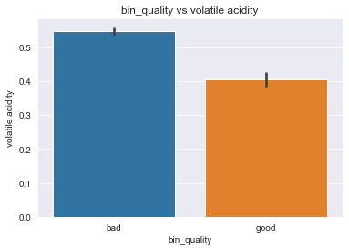

```python
# bin_quality vs volatile acidity
sns.barplot(data = df, x = "bin_quality", y="volatile acidity")
plt.title("bin_quality vs volatile acidity")
```

Increase in the volatile acidity will decrease the quality of the wine and vise versa

## *6. Decision Tree Classification*

```python
# Creating Input and output Varibles

X = df[["alcohol", "sulphates", "citric acid", "fixed acidity"]]
y = df["bin_quality"]
```

```python
# Training and fitting the model and making predictions

from sklearn.tree import DecisionTreeClassifier
from sklearn.metrics import accuracy_score

model = DecisionTreeClassifier().fit(X, y)

predict_value = model.predict([[9.5, 0.50, 0.02, 7.0]])
predict_value
```

```
array(['bad'], dtype=object)
```

```python
# Checking the accuracy of the model

model.score(X,y)
```

```
1.0
```

```python
# Testing the model by using the method of splitting the data into training and testing sets in the ratio of 80:20

from sklearn.model_selection import train_test_split
from sklearn.metrics import accuracy_score

X_train, X_test, y_train, y_test = train_test_split(X, y, test_size= 0.2)

# Creating and fit the model
model = DecisionTreeClassifier().fit(X_train, y_train)

# Prediction
pred_values = model.predict(X_test)
pred_values
```

[output not shown]

```python
score = accuracy_score(y_test, pred_values)
score
```

```
0.903125
```

## *7. K Nearest Neighbor*

```python
# Creating the input and output variables

X = df[["alcohol", "sulphates", "citric acid", "fixed acidity"]]
y = df["bin_quality"]
```

```python
# Training the model and fitting it

from sklearn.neighbors import KNeighborsClassifier

model = KNeighborsClassifier(n_neighbors= 5)
model.fit(X, y)
```

```
KNeighborsClassifier()
```

```python
# Making the predictions

predict_value = model.predict([[9.5, 0.50, 0.02, 7.0]])
predict_value
```

```
array(['bad'], dtype=object)
```

```python
# metrices for evaluation
# split data into test and train (80/20)

from sklearn.model_selection import train_test_split
from sklearn.metrics import accuracy_score

X_train, X_test, y_train, y_test =  train_test_split(X, y, test_size=0.2)

# Create a model
model = KNeighborsClassifier()

# Fitting a model
model.fit(X_train, y_train)

predict_value = model.predict(X_test)
predict_value
```

[output not shown]

```python
score = accuracy_score(y_test, predict_value)
print("The accuracy score of our model is = ", score)
```

```
The accuracy score of our model is =  0.85
```